# Лабораторна робота 1. Побудова простого лінійного бінарного класифікатора

[Хань Євгеній](https://github.com/amx122) , 2024

## Завдання для самостійної роботи

1. Імпортувати дані для навчальної вибірки згідно з індивідуальним варіантом (імпорт організувати з файлу).
2. Побудувати бінарний класифікатор і вивести результати бінарної класифікації на графіку.
3. Дати відповіді на контрольні запитання.
4. Відправити результати роботи у файлі lab_1_StudentLastName.ipynb до віддаленого репозиторію на GіtHub.

# Виконання завдання:

```
[1.3, -1]
```

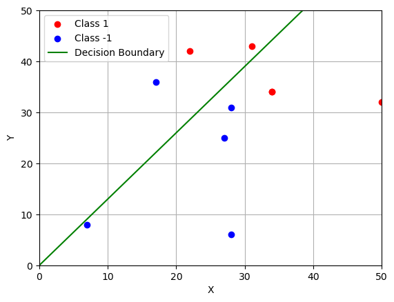

```python
import numpy as np
import matplotlib.pyplot as plt

# Навчальні дані
x_train = np.array([[28, 31],
                    [50, 32],
                    [17, 36],
                    [34, 34],
                    [28, 6],
                    [31, 43],
                    [7, 8],
                    [27, 25],
                    [34, 34],
                    [22, 42]])
y_train = np.array([-1, 1, -1, 1, -1, 1, -1, -1, 1, 1])

n_train = len(x_train)                          # Розмір навчальної вибірки
w = [0, -1]                                     # Початкове значення ваги w
a = lambda x: np.sign(x[0]*w[0] + x[1]*w[1])    # Правило класифікації
L = 0.1                                         # Крок зміни ваги
e = 0.1                                         # Невелике додаток до w0, щоб забезпечити зазор між лінією розділення та областю
c = 0

last_error_index = -1                           # Індекс останньої помилкової спостереження

# Тренування моделі
for _ in range(100):
    c += 1
    for i in range(n_train):                # Ітерація по спостереженням
        if y_train[i]*a(x_train[i]) < 0:    # Якщо помилка класифікації,
            w[0] = w[0] + L * y_train[i]    # То коригування ваги w0
            last_error_index = i

    Q = sum([1 for i in range(n_train) if y_train[i]*a(x_train[i]) < 0])
    if Q == 0:      # Показник якості класифікації (кількість помилок)
        break       # Зупинка, якщо всі класифікуються правильно

if last_error_index > -1:
    w[0] = w[0] + e * y_train[last_error_index]

print(w)

# Визначення координат для лінії розділення
line_x = np.linspace(0, 50, 100)
line_y = -(w[0]*line_x)/w[1]

# Розділення даних по класам
x_0 = x_train[y_train == 1]
x_1 = x_train[y_train == -1]

# Візуалізація результатів
plt.scatter(x_0[:, 0], x_0[:, 1], color='red', label='Class 1')
plt.scatter(x_1[:, 0], x_1[:, 1], color='blue', label='Class -1')
plt.plot(line_x, line_y, color='green', label='Decision Boundary')

plt.xlim([0, 50])
plt.ylim([0, 50])
plt.ylabel("Y")
plt.xlabel("X")
plt.legend()
plt.grid(True)
plt.show()
```

# Контрольні запитання

1. Основні принципи розпізнавання образів у контексті машинного навчання включають:
   - Використання навчальних даних для тренування моделі.
   - Використання алгоритмів класифікації та регресії для встановлення зв'язків між вхідними даними та вихідними мітками.
2. Навчальна вибірка - це набір даних, які використовуються для тренування моделі. Вона важлива для процесу розпізнавання образів, оскільки визначає, яким чином модель буде вчитися розпізнавати образи на основі вхідних даних та їх відповідних міток.
3. Постановка задачі бінарної класифікації полягає в тому, щоб розділити набір даних на два класи або категорії.
4. Рівняння гіперплощини - це лінійна розділяюча поверхня, яка використовується для розділення об'єктів у просторі на два класи. Це використовується для розв'язання задачі бінарної класифікації шляхом встановлення границі між класами.
5. Кроки для розв'язання простої задачі бінарної класифікації за допомогою машинного навчання включають:
   1. Збір та підготовка навчальних даних.
   2. Вибір моделі класифікації (наприклад, логістична регресія, метод опорних векторів тощо).
   3. Тренування моделі на навчальній вибірці.
   4. Оцінка та налаштування моделі за допомогою валідаційної вибірки.
   5. Тестування моделі на тестовій вибірці для оцінки її ефективності.